```python
import pandas as pd
import numpy as np
import matplotlib.pyplot as plt
import seaborn as sns
%matplotlib inline
```

# 1. Understanding the gap that exist between Food produced and Food consumed in Africa

```python
## Understanding the food production pattern
```

```python
## Importing the food production data of African countries from 2004-2013

Food_production = pd.read_csv('Africa Food Production (2004 - 2013).csv')
Food_production.head()
```

|  | Country | Item | Year | Value |
| --- | --- | --- | --- | --- |
| 0 | Algeria | Wheat and products | 2004 | 2731 |
| 1 | Algeria | Wheat and products | 2005 | 2415 |
| 2 | Algeria | Wheat and products | 2006 | 2688 |
| 3 | Algeria | Wheat and products | 2007 | 2319 |
| 4 | Algeria | Wheat and products | 2008 | 1111 |

# The Column names for the data.

The data supplies Various Countries in Africa along with the various types of food item produced in each country with the volume produced per year

```python
 Food_production.columns
```

```
Index(['Country', 'Item', 'Year', 'Value'], dtype='object')
```

##### The Data has 4 columns with 23110 rows of information

```python
Food_production.shape
```

```
(23110, 4)
```

```python
## Information about the data used

Food_production.info()
```

```
<class 'pandas.core.frame.DataFrame'>
RangeIndex: 23110 entries, 0 to 23109
Data columns (total 4 columns):
 #   Column   Non-Null Count  Dtype
---  ------   --------------  -----
 0   Country  23110 non-null  object
 1   Item     23110 non-null  object
 2   Year     23110 non-null  int64
 3   Value    23110 non-null  int64
dtypes: int64(2), object(2)
memory usage: 722.3+ KB
```

```python
# This is to give a quick summary statistics of the food production data (mean, Standard deviation, Minimum value,
# 25% & 75% quartile, meidan value, and the Maximum value)

Food_production.describe()
```

|  | Year | Value |
| --- | --- | --- |
| count | 23110.000000 | 23110.000000 |
| mean | 2008.498269 | 327.785201 |
| std | 2.871740 | 1607.940343 |
| min | 2004.000000 | 0.000000 |
| 25% | 2006.000000 | 3.000000 |
| 50% | 2008.000000 | 18.000000 |
| 75% | 2011.000000 | 108.000000 |
| max | 2013.000000 | 54000.000000 |

```python
Food_Country = Food_production.groupby(['Country', 'Year']).sum()
Food_Country.head(10)
```

| Country | Year | Value |
| --- | --- | --- |
| Algeria | 2004 | 15536 |
|  | 2005 | 15667 |
|  | 2006 | 16417 |
|  | 2007 | 14763 |
|  | 2008 | 13841 |
|  | 2009 | 19820 |
|  | 2010 | 20263 |
|  | 2011 | 21778 |
|  | 2012 | 24206 |
|  | 2013 | 26359 |

# A line plot to view the dispersion of food production amongst countries in africa

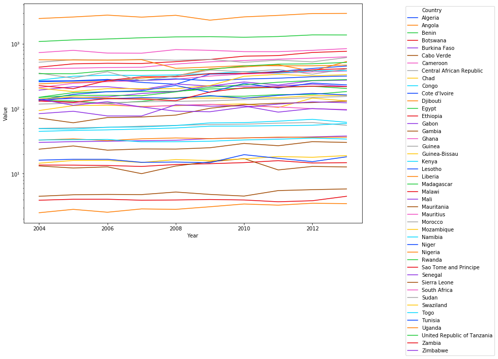

```python
line_plot = sns.lineplot(x="Year", y="Value", hue="Country", palette = 'bright', ci = None, data= Food_production)
line_plot.set_yscale('log')
line_plot.legend(loc='upper right', bbox_to_anchor=(1.4, 1))
fig = plt.gcf()
fig.set_size_inches(12, 8)
```

### From the line plot above it can be seen that some countries produce way more than other countries in the region, the plot shows a posibility of the presence of outliers in the data used

#### To identify the various countries and how well they produce according to their rank in production, the data has to be grouped by the countries and sorted according to the summary statistics of each country

```python
Country_group_p = Food_production.groupby(['Country'])
Country_group_p['Value'].describe().sort_values(by='max', ascending=False)
```

| Country | count | mean | std | min | 25% | 50% | 75% | max |
| --- | --- | --- | --- | --- | --- | --- | --- | --- |
| Nigeria | 610.0 | 2668.901639 | 7367.238559 | 0.0 | 82.00 | 425.0 | 1949.25 | 54000.0 |
| South Africa | 750.0 | 772.789333 | 2523.373788 | 0.0 | 11.00 | 56.5 | 460.00 | 21265.0 |
| Egypt | 700.0 | 1253.568571 | 2789.860428 | 0.0 | 18.00 | 108.0 | 845.50 | 17014.0 |
| Angola | 540.0 | 362.035185 | 1603.100582 | 0.0 | 4.00 | 22.0 | 103.00 | 16412.0 |
| Ghana | 580.0 | 508.627586 | 1778.998859 | 0.0 | 12.00 | 61.5 | 206.00 | 15990.0 |
| Mozambique | 620.0 | 254.167742 | 1014.112431 | 0.0 | 8.00 | 25.0 | 104.25 | 10094.0 |
| Uganda | 560.0 | 497.180357 | 1199.717299 | 0.0 | 15.00 | 50.5 | 264.25 | 9686.0 |
| Sudan | 540.0 | 558.488889 | 1407.710213 | 0.0 | 14.00 | 114.0 | 405.50 | 7542.0 |
| Morocco | 770.0 | 353.014286 | 842.107917 | 0.0 | 3.00 | 27.0 | 221.75 | 6934.0 |
| Ethiopia | 600.0 | 584.488333 | 1154.826265 | 0.0 | 18.00 | 90.5 | 363.00 | 6674.0 |
| United Republic of Tanzania | 790.0 | 421.268354 | 948.206828 | 0.0 | 8.00 | 38.0 | 303.75 | 6158.0 |
| Cote d'Ivoire | 640.0 | 285.134375 | 788.336974 | 0.0 | 7.00 | 33.5 | 160.00 | 5945.0 |
| Kenya | 750.0 | 342.496000 | 916.050808 | 0.0 | 4.00 | 25.0 | 159.25 | 5900.0 |
| Swaziland | 420.0 | 149.202381 | 778.604255 | 0.0 | 0.00 | 2.0 | 17.00 | 5450.0 |
| Mauritius | 460.0 | 112.576087 | 658.560287 | 0.0 | 0.00 | 1.0 | 5.25 | 5280.0 |
| Algeria | 580.0 | 325.258621 | 746.119621 | 0.0 | 1.00 | 14.0 | 209.75 | 4928.0 |
| Malawi | 480.0 | 320.243750 | 864.250885 | 0.0 | 4.00 | 30.0 | 151.00 | 4814.0 |
| Cameroon | 650.0 | 304.107692 | 628.245740 | 0.0 | 7.00 | 53.0 | 231.75 | 4596.0 |
| Zimbabwe | 640.0 | 114.556250 | 434.469957 | 0.0 | 3.00 | 15.0 | 60.00 | 4121.0 |
| Zambia | 480.0 | 172.293750 | 535.111948 | 0.0 | 3.00 | 23.0 | 81.00 | 4000.0 |
| Niger | 430.0 | 201.879070 | 525.849229 | 0.0 | 6.00 | 20.5 | 112.50 | 3862.0 |
| Sierra Leone | 500.0 | 95.474000 | 383.956496 | 0.0 | 3.00 | 11.0 | 44.25 | 3810.0 |
| Benin | 590.0 | 149.274576 | 535.228615 | 0.0 | 4.00 | 15.0 | 53.00 | 3788.0 |
| Madagascar | 690.0 | 192.856522 | 587.287399 | 0.0 | 4.00 | 10.0 | 70.00 | 3621.0 |
| Burkina Faso | 430.0 | 232.858140 | 550.321606 | 0.0 | 7.25 | 39.5 | 135.25 | 3337.0 |
| Rwanda | 460.0 | 206.900000 | 551.507282 | 0.0 | 4.00 | 17.0 | 102.25 | 3292.0 |
| Tunisia | 610.0 | 151.988525 | 340.200445 | 0.0 | 2.00 | 14.5 | 103.50 | 1987.0 |
| Mali | 480.0 | 192.275000 | 360.821516 | 0.0 | 8.00 | 41.0 | 161.00 | 1772.0 |
| Guinea | 500.0 | 133.696000 | 236.544292 | 0.0 | 8.00 | 34.0 | 176.50 | 1370.0 |
| Congo | 500.0 | 51.582000 | 178.518944 | 0.0 | 2.00 | 5.0 | 20.00 | 1250.0 |
| Chad | 390.0 | 115.584615 | 167.871085 | 0.0 | 17.25 | 40.0 | 110.75 | 1172.0 |
| Togo | 560.0 | 57.419643 | 162.836268 | 0.0 | 1.00 | 9.0 | 24.00 | 999.0 |
| Senegal | 520.0 | 95.026923 | 173.813210 | 0.0 | 4.00 | 22.0 | 101.25 | 921.0 |
| Central African Republic | 450.0 | 55.380000 | 109.224723 | 0.0 | 4.25 | 17.5 | 66.75 | 706.0 |
| Liberia | 420.0 | 34.897619 | 90.009130 | 0.0 | 2.00 | 5.0 | 18.00 | 533.0 |
| Mauritania | 380.0 | 26.418421 | 65.798855 | 0.0 | 1.00 | 5.0 | 20.00 | 410.0 |
| Namibia | 430.0 | 33.016279 | 72.442001 | 0.0 | 0.00 | 5.0 | 19.00 | 360.0 |
| Gabon | 400.0 | 33.915000 | 72.503722 | 0.0 | 1.00 | 3.0 | 20.25 | 325.0 |
| Guinea-Bissau | 440.0 | 16.581818 | 27.910002 | 0.0 | 2.00 | 5.0 | 22.25 | 200.0 |
| Gambia | 360.0 | 13.052778 | 25.038689 | 0.0 | 1.00 | 3.0 | 12.00 | 158.0 |
| Lesotho | 230.0 | 16.456522 | 25.791325 | 0.0 | 1.00 | 6.0 | 20.00 | 128.0 |
| Botswana | 340.0 | 14.141176 | 26.206871 | 0.0 | 0.00 | 3.0 | 13.50 | 120.0 |
| Sao Tome and Principe | 290.0 | 3.972414 | 8.984373 | 0.0 | 0.00 | 1.0 | 3.00 | 54.0 |
| Djibouti | 220.0 | 3.027273 | 6.774191 | 0.0 | 0.00 | 1.0 | 2.00 | 36.0 |
| Cabo Verde | 330.0 | 5.024242 | 6.994093 | 0.0 | 0.00 | 2.0 | 6.75 | 30.0 |

#### From the Summary statistics gotten it can be seen that Nigeria, South-Africa, and Egypt are the highest food producers in Africa and while Sao Tome and Principle, Djibouti, and Cape Verde are the lowest producers in Africa

#### A study of the various country means with their quartile values shows that the various countries don't uniformly distribute their prodcution power across various items but they have specific Items they produce more that others

```python
# Grouping and Ranking the production according to the Years of Production

Production_Year_value = pd.pivot_table(Food_production, index= 'Year', values='Value', aggfunc = 'sum')
Production_Year_value.sort_values('Value', ascending = False)
```

| Year | Value |
| --- | --- |
| 2013 | 872571 |
| 2012 | 841667 |
| 2011 | 812214 |
| 2010 | 786466 |
| 2009 | 746870 |
| 2008 | 736804 |
| 2006 | 718602 |
| 2007 | 705659 |
| 2005 | 691257 |
| 2004 | 663006 |

##### The Analysis shows that 2013 is the year with the highest production rate and 2004 with the lowest production rate across Africa

##### A graphical illustration to show the production rate ranking per year

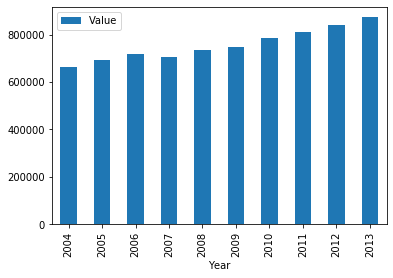

```python
Production_Year_value.plot(kind='bar')
```

#### A Breakdown of the average yearly production across each country is shown in the table below

```python
Production_yearly_value = pd.pivot_table(Food_production, index = 'Country', columns = 'Year', values = 'Value')
Production_yearly_value
```

| Year Country | 2004 | 2005 | 2006 | 2007 | 2008 | 2009 | 2010 | 2011 | 2012 | 2013 |
| --- | --- | --- | --- | --- | --- | --- | --- | --- | --- | --- |
| Algeria | 267.862069 | 270.120690 | 283.051724 | 254.534483 | 238.637931 | 341.724138 | 349.362069 | 375.482759 | 417.344828 | 454.465517 |
| Angola | 241.259259 | 255.759259 | 264.148148 | 296.759259 | 320.148148 | 411.925926 | 440.833333 | 475.407407 | 379.722222 | 534.388889 |
| Benin | 134.966102 | 131.593220 | 120.508475 | 130.152542 | 147.847458 | 156.525424 | 155.932203 | 165.000000 | 166.050847 | 184.169492 |
| Botswana | 13.558824 | 13.529412 | 13.352941 | 12.911765 | 13.823529 | 14.235294 | 14.794118 | 15.852941 | 14.588235 | 14.764706 |
| Burkina Faso | 193.558140 | 218.418605 | 218.441860 | 196.906977 | 241.232558 | 223.418605 | 258.651163 | 231.488372 | 270.558140 | 275.906977 |
| Cabo Verde | 4.484848 | 4.727273 | 4.787879 | 4.757576 | 5.212121 | 4.787879 | 4.515152 | 5.484848 | 5.666667 | 5.818182 |
| Cameroon | 211.369231 | 246.661538 | 260.953846 | 271.646154 | 283.984615 | 318.907692 | 343.230769 | 353.292308 | 369.907692 | 381.123077 |
| Central African Republic | 49.822222 | 50.955556 | 51.755556 | 53.911111 | 55.422222 | 57.088889 | 57.822222 | 60.044444 | 61.355556 | 55.622222 |
| Chad | 93.846154 | 111.794872 | 113.410256 | 108.794872 | 111.076923 | 115.794872 | 118.794872 | 104.358974 | 145.846154 | 132.128205 |
| Congo | 44.820000 | 46.360000 | 47.300000 | 48.760000 | 50.600000 | 53.860000 | 54.140000 | 54.900000 | 55.720000 | 59.360000 |
| Cote d'Ivoire | 260.546875 | 267.406250 | 275.937500 | 274.531250 | 289.000000 | 271.109375 | 286.921875 | 295.593750 | 311.234375 | 319.062500 |
| Djibouti | 2.500000 | 2.818182 | 2.545455 | 2.863636 | 2.818182 | 3.090909 | 3.409091 | 3.272727 | 3.500000 | 3.454545 |
| Egypt | 1085.557143 | 1148.885714 | 1188.442857 | 1240.400000 | 1278.414286 | 1291.071429 | 1263.571429 | 1296.671429 | 1373.414286 | 1369.257143 |
| Ethiopia | 437.433333 | 492.116667 | 501.950000 | 498.183333 | 531.333333 | 575.133333 | 645.116667 | 659.550000 | 735.700000 | 768.366667 |
| Gabon | 30.275000 | 31.150000 | 31.575000 | 32.225000 | 32.700000 | 34.675000 | 35.600000 | 36.075000 | 36.850000 | 38.025000 |
| Gambia | 13.138889 | 12.222222 | 12.722222 | 10.000000 | 13.111111 | 15.250000 | 17.055556 | 11.416667 | 12.916667 | 12.694444 |
| Ghana | 414.482759 | 421.517241 | 431.965517 | 435.965517 | 487.758621 | 528.396552 | 554.137931 | 580.172414 | 601.034483 | 630.844828 |
| Guinea | 117.820000 | 121.980000 | 123.320000 | 127.860000 | 130.240000 | 132.120000 | 138.080000 | 141.680000 | 149.160000 | 154.700000 |
| Guinea-Bissau | 14.477273 | 15.977273 | 16.022727 | 14.863636 | 16.477273 | 15.909091 | 16.886364 | 18.340909 | 17.886364 | 18.977273 |
| Kenya | 275.520000 | 316.600000 | 328.746667 | 325.773333 | 332.373333 | 347.320000 | 373.213333 | 354.733333 | 384.680000 | 386.000000 |
| Lesotho | 16.130435 | 16.652174 | 16.652174 | 14.956522 | 15.086957 | 14.739130 | 19.608696 | 17.260870 | 15.304348 | 18.173913 |
| Liberia | 32.904762 | 34.357143 | 32.333333 | 34.428571 | 35.500000 | 34.690476 | 35.476190 | 36.547619 | 36.238095 | 36.500000 |
| Madagascar | 150.144928 | 177.217391 | 182.724638 | 184.347826 | 185.130435 | 201.855072 | 206.014493 | 213.550725 | 222.362319 | 205.217391 |
| Malawi | 227.437500 | 203.875000 | 272.458333 | 310.583333 | 310.625000 | 347.437500 | 351.395833 | 366.020833 | 397.375000 | 415.229167 |
| Mali | 130.729167 | 150.687500 | 152.104167 | 171.854167 | 184.479167 | 226.104167 | 222.312500 | 224.437500 | 239.291667 | 220.750000 |
| Mauritania | 23.842105 | 26.736842 | 23.026316 | 24.026316 | 23.921053 | 25.078947 | 29.210526 | 26.947368 | 31.105263 | 30.289474 |
| Mauritius | 132.195652 | 124.347826 | 118.934783 | 106.326087 | 113.043478 | 116.717391 | 110.000000 | 106.760870 | 100.217391 | 97.217391 |
| Morocco | 353.818182 | 296.025974 | 371.350649 | 271.025974 | 320.506494 | 394.207792 | 371.129870 | 402.311688 | 340.727273 | 409.038961 |
| Mozambique | 207.532258 | 183.725806 | 204.274194 | 203.870968 | 203.967742 | 227.532258 | 316.306452 | 338.322581 | 321.596774 | 334.548387 |
| Namibia | 33.046512 | 33.348837 | 33.674419 | 30.953488 | 31.046512 | 31.604651 | 33.069767 | 33.883721 | 35.395349 | 34.139535 |
| Niger | 136.093023 | 166.744186 | 182.674419 | 189.581395 | 228.372093 | 179.418605 | 245.953488 | 207.511628 | 249.279070 | 233.162791 |
| Nigeria | 2456.672131 | 2592.606557 | 2770.278689 | 2578.245902 | 2753.032787 | 2315.901639 | 2601.786885 | 2744.311475 | 2931.409836 | 2944.770492 |
| Rwanda | 149.195652 | 160.217391 | 160.978261 | 158.586957 | 181.978261 | 213.869565 | 234.347826 | 256.021739 | 272.239130 | 281.565217 |
| Sao Tome and Principe | 3.896552 | 4.034483 | 4.034483 | 3.896552 | 3.931034 | 4.000000 | 3.931034 | 3.689655 | 3.827586 | 4.482759 |
| Senegal | 84.000000 | 91.480769 | 77.500000 | 77.384615 | 115.134615 | 109.403846 | 110.326923 | 88.711538 | 100.711538 | 95.615385 |
| Sierra Leone | 71.840000 | 60.800000 | 73.140000 | 74.620000 | 79.820000 | 101.680000 | 115.660000 | 121.660000 | 124.560000 | 130.960000 |
| South Africa | 732.653333 | 794.360000 | 720.320000 | 717.266667 | 815.493333 | 794.533333 | 758.173333 | 757.173333 | 794.413333 | 843.506667 |
| Sudan | 520.836364 | 570.345455 | 560.618182 | 576.163636 | 558.745455 | 577.781818 | 519.418182 | 561.254545 | 527.460000 | 614.540000 |
| Swaziland | 141.666667 | 152.547619 | 145.809524 | 145.142857 | 146.404762 | 145.904762 | 146.595238 | 148.119048 | 158.809524 | 161.023810 |
| Togo | 49.375000 | 48.750000 | 51.928571 | 52.464286 | 55.089286 | 60.517857 | 61.142857 | 64.375000 | 68.714286 | 61.839286 |
| Tunisia | 139.393443 | 144.180328 | 142.426230 | 148.393443 | 144.950820 | 159.524590 | 145.147541 | 160.491803 | 172.278689 | 163.098361 |
| Uganda | 568.196429 | 565.089286 | 560.982143 | 569.482143 | 419.482143 | 438.821429 | 461.607143 | 459.000000 | 459.125000 | 470.017857 |
| United Republic of Tanzania | 346.696203 | 345.936709 | 385.721519 | 388.265823 | 390.835443 | 402.886076 | 455.772152 | 486.379747 | 493.113924 | 517.075949 |
| Zambia | 131.458333 | 126.562500 | 143.312500 | 140.479167 | 132.979167 | 181.145833 | 210.187500 | 215.229167 | 222.291667 | 219.291667 |
| Zimbabwe | 140.375000 | 113.109375 | 128.515625 | 106.593750 | 91.828125 | 89.906250 | 105.890625 | 117.984375 | 127.703125 | 123.656250 |

```python
Food_production.isnull().sum()
```

```
Country    0
Item       0
Year       0
Value      0
dtype: int64
```

##### A summary stats of the yearly production values will also give an insight to the production rate

```python
Production_yearly_value.describe()
```

| Year | 2004 | 2005 | 2006 | 2007 | 2008 | 2009 | 2010 | 2011 | 2012 | 2013 |
| --- | --- | --- | --- | --- | --- | --- | --- | --- | --- | --- |
| count | 45.000000 | 45.000000 | 45.000000 | 45.000000 | 45.000000 | 45.000000 | 45.000000 | 45.000000 | 45.000000 | 45.000000 |
| mean | 241.942839 | 252.540736 | 262.371373 | 258.238686 | 269.413240 | 273.502387 | 288.945182 | 297.706114 | 310.193038 | 321.440897 |
| std | 399.107266 | 421.928882 | 444.737062 | 423.258291 | 447.865676 | 396.510729 | 428.995125 | 450.290324 | 478.012597 | 484.922039 |
| min | 2.500000 | 2.818182 | 2.545455 | 2.863636 | 2.818182 | 3.090909 | 3.409091 | 3.272727 | 3.500000 | 3.454545 |
| 25% | 44.820000 | 46.360000 | 47.300000 | 48.760000 | 50.600000 | 53.860000 | 54.140000 | 54.900000 | 55.720000 | 55.622222 |
| 50% | 136.093023 | 144.180328 | 143.312500 | 145.142857 | 146.404762 | 159.524590 | 155.932203 | 165.000000 | 172.278689 | 184.169492 |
| 75% | 260.546875 | 267.406250 | 275.937500 | 274.531250 | 310.625000 | 347.320000 | 351.395833 | 366.020833 | 379.722222 | 409.038961 |
| max | 2456.672131 | 2592.606557 | 2770.278689 | 2578.245902 | 2753.032787 | 2315.901639 | 2601.786885 | 2744.311475 | 2931.409836 | 2944.770492 |

#### A look at the summary stats of the yearly production helps to indetify outliers when the maximum values are compared to the 75% quartile values, as this raises questions to why there is so much variation betwewn the upper quartile and the maximum value

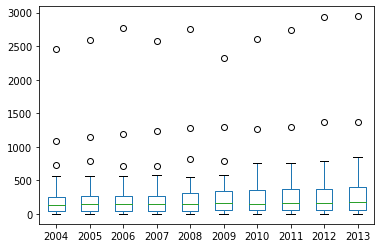

```python
# Box plot to identify outliers present in the data

Production_yearly_value.plot(kind='box')
```

### After a careful study of the food production data, an understanding of the food consumption/supply data is also equally important

```python
# TO import the food supply data

Food_supply = pd.read_csv('Africa Food Supply (2004 - 2013).csv')
Food_supply.head()
```

|  | Country | Year | Value |
| --- | --- | --- | --- |
| 0 | Algeria | 2004 | 2987 |
| 1 | Algeria | 2005 | 2958 |
| 2 | Algeria | 2006 | 3047 |
| 3 | Algeria | 2007 | 3041 |
| 4 | Algeria | 2008 | 3048 |

# The Column names for the data.

```python
 Food_supply.columns
```

```
Index(['Country', 'Year', 'Value'], dtype='object')
```

##### The Data has 3 columns with 450 rows of information

```python
 Food_supply.shape
```

```
(450, 3)
```

```python
## Information about the data used

Food_supply.info()
```

```
<class 'pandas.core.frame.DataFrame'>
RangeIndex: 450 entries, 0 to 449
Data columns (total 3 columns):
 #   Column   Non-Null Count  Dtype
---  ------   --------------  -----
 0   Country  450 non-null    object
 1   Year     450 non-null    int64
 2   Value    450 non-null    int64
dtypes: int64(2), object(1)
memory usage: 10.7+ KB
```

```python
# This is to give a quick summary statistics of the food production data (mean, Standard deviation, Minimum value,
# 25% & 75% quartile, meidan value, and the Maximum value)

Food_supply.describe()
```

|  | Year | Value |
| --- | --- | --- |
| count | 450.000000 | 450.000000 |
| mean | 2008.500000 | 2469.775556 |
| std | 2.875478 | 379.140143 |
| min | 2004.000000 | 1781.000000 |
| 25% | 2006.000000 | 2174.000000 |
| 50% | 2008.500000 | 2376.000000 |
| 75% | 2011.000000 | 2681.750000 |
| max | 2013.000000 | 3561.000000 |

```python
consumption_Country = Food_supply.groupby(['Country', 'Year']).sum()
consumption_Country.head(10)
```

| Country | Year | Value |
| --- | --- | --- |
| Algeria | 2004 | 2987 |
|  | 2005 | 2958 |
|  | 2006 | 3047 |
|  | 2007 | 3041 |
|  | 2008 | 3048 |
|  | 2009 | 3110 |
|  | 2010 | 3142 |
|  | 2011 | 3217 |
|  | 2012 | 3272 |
|  | 2013 | 3296 |

# A line plot to view the dispersion of food consumption/supply amongst countries in africa

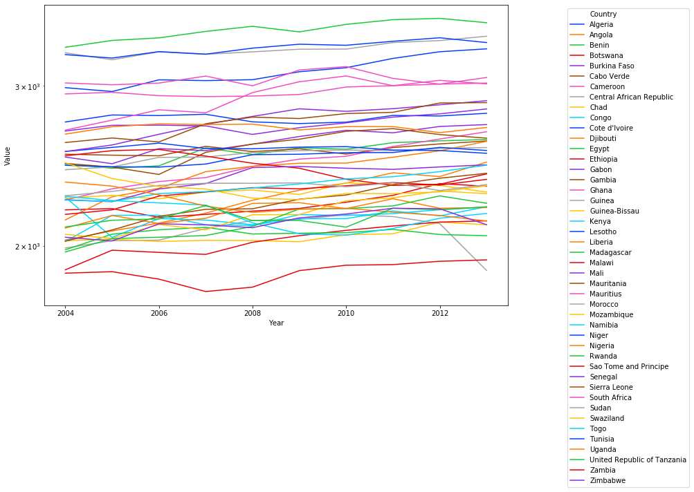

```python
line_plot = sns.lineplot(x="Year", y="Value", hue="Country", palette = 'bright', ci = None, data= Food_supply)
line_plot.set_yscale('log')
line_plot.legend(loc='upper right', bbox_to_anchor=(1.4, 1))
fig = plt.gcf()
fig.set_size_inches(12, 8)
```

### From the line plot above it can be seen that some countries consume more than other countries in the region, the plot shows a posibility of the presence of outliers in the data used

#### To identify the various countries and how well they produce according to their rank in production, the data has to be grouped by the countries and sorted according to the summary statistics of each country

```python
Country_group_s = Food_supply.groupby(['Country'])
Country_group_s['Value'].describe().sort_values(by='max', ascending=False)
```

| Country | count | mean | std | min | 25% | 50% | 75% | max |
| --- | --- | --- | --- | --- | --- | --- | --- | --- |
| Egypt | 10.0 | 3458.0 | 83.074264 | 3309.0 | 3402.00 | 3467.5 | 3518.25 | 3561.0 |
| Morocco | 10.0 | 3296.7 | 59.282844 | 3206.0 | 3265.00 | 3282.0 | 3335.25 | 3403.0 |
| Tunisia | 10.0 | 3305.5 | 55.618242 | 3220.0 | 3257.25 | 3314.0 | 3345.50 | 3390.0 |
| Algeria | 10.0 | 3111.8 | 117.420233 | 2958.0 | 3042.50 | 3079.0 | 3198.25 | 3296.0 |
| Mauritius | 10.0 | 3054.3 | 50.933617 | 3001.0 | 3016.00 | 3040.5 | 3073.25 | 3151.0 |
| Ghana | 10.0 | 2918.0 | 140.329770 | 2682.0 | 2808.25 | 2976.0 | 3028.00 | 3077.0 |
| South Africa | 10.0 | 2962.9 | 40.123282 | 2920.0 | 2929.25 | 2946.0 | 2999.50 | 3022.0 |
| Mali | 10.0 | 2750.2 | 120.955272 | 2540.0 | 2671.00 | 2795.0 | 2831.75 | 2890.0 |
| Mauritania | 10.0 | 2744.3 | 103.430116 | 2599.0 | 2653.25 | 2767.0 | 2803.75 | 2876.0 |
| Gabon | 10.0 | 2729.9 | 54.345500 | 2653.0 | 2702.00 | 2715.5 | 2762.00 | 2830.0 |
| Cote d'Ivoire | 10.0 | 2766.6 | 27.661445 | 2727.0 | 2738.25 | 2781.5 | 2786.25 | 2799.0 |
| Nigeria | 10.0 | 2698.8 | 23.980548 | 2655.0 | 2687.25 | 2705.5 | 2716.50 | 2725.0 |
| Burkina Faso | 10.0 | 2607.2 | 88.219172 | 2463.0 | 2549.25 | 2613.5 | 2676.75 | 2720.0 |
| Gambia | 10.0 | 2569.5 | 103.982103 | 2397.0 | 2482.50 | 2605.0 | 2646.00 | 2692.0 |
| Cameroon | 10.0 | 2460.3 | 138.728392 | 2246.0 | 2360.00 | 2469.0 | 2557.25 | 2671.0 |
| Benin | 10.0 | 2537.8 | 67.994771 | 2435.0 | 2476.00 | 2559.5 | 2589.75 | 2619.0 |
| Cabo Verde | 10.0 | 2551.4 | 33.200402 | 2513.0 | 2523.25 | 2549.0 | 2572.00 | 2609.0 |
| Djibouti | 10.0 | 2416.5 | 140.844477 | 2136.0 | 2339.00 | 2456.5 | 2494.75 | 2607.0 |
| Lesotho | 10.0 | 2558.8 | 18.498048 | 2529.0 | 2547.75 | 2559.0 | 2568.50 | 2595.0 |
| Niger | 10.0 | 2502.4 | 47.192749 | 2442.0 | 2455.00 | 2521.5 | 2533.75 | 2567.0 |
| Guinea | 10.0 | 2518.0 | 48.858071 | 2426.0 | 2503.50 | 2540.0 | 2549.00 | 2566.0 |
| Sao Tome and Principe | 10.0 | 2446.2 | 84.319235 | 2331.0 | 2376.00 | 2450.5 | 2512.50 | 2554.0 |
| Angola | 10.0 | 2255.6 | 151.032888 | 2030.0 | 2132.50 | 2274.0 | 2374.25 | 2473.0 |
| Swaziland | 10.0 | 2317.1 | 64.490223 | 2249.0 | 2283.25 | 2301.5 | 2328.00 | 2469.0 |
| Senegal | 10.0 | 2378.4 | 86.347103 | 2237.0 | 2318.00 | 2431.5 | 2442.00 | 2456.0 |
| Togo | 10.0 | 2333.9 | 71.444539 | 2238.0 | 2286.00 | 2328.0 | 2379.75 | 2454.0 |
| Sierra Leone | 10.0 | 2229.1 | 123.308511 | 2024.0 | 2164.75 | 2224.0 | 2320.00 | 2404.0 |
| Malawi | 10.0 | 2292.5 | 66.208845 | 2166.0 | 2275.00 | 2314.5 | 2332.00 | 2367.0 |
| Uganda | 10.0 | 2220.5 | 73.179004 | 2130.0 | 2177.25 | 2197.0 | 2260.00 | 2351.0 |
| Guinea-Bissau | 10.0 | 2296.3 | 32.721213 | 2253.0 | 2274.25 | 2292.5 | 2324.25 | 2346.0 |
| Sudan | 10.0 | 2323.8 | 25.999145 | 2271.0 | 2306.50 | 2333.5 | 2344.00 | 2346.0 |
| Botswana | 10.0 | 2226.3 | 66.337605 | 2150.0 | 2185.75 | 2198.5 | 2263.25 | 2342.0 |
| Mozambique | 10.0 | 2170.2 | 96.098098 | 2038.0 | 2090.00 | 2164.5 | 2254.75 | 2298.0 |
| Rwanda | 10.0 | 2130.9 | 102.089775 | 1969.0 | 2046.25 | 2148.5 | 2209.25 | 2270.0 |
| Namibia | 10.0 | 2160.2 | 77.668526 | 2055.0 | 2097.50 | 2158.0 | 2227.00 | 2268.0 |
| Congo | 10.0 | 2153.0 | 58.469365 | 2043.0 | 2136.75 | 2143.0 | 2178.25 | 2263.0 |
| Liberia | 10.0 | 2182.7 | 52.681538 | 2092.0 | 2148.75 | 2199.0 | 2221.25 | 2254.0 |
| United Republic of Tanzania | 10.0 | 2155.0 | 44.803274 | 2097.0 | 2132.25 | 2137.5 | 2198.00 | 2215.0 |
| Kenya | 10.0 | 2145.3 | 53.298009 | 2022.0 | 2122.50 | 2161.0 | 2168.75 | 2206.0 |
| Zimbabwe | 10.0 | 2120.9 | 58.762138 | 2025.0 | 2097.75 | 2112.5 | 2162.75 | 2200.0 |
| Central African Republic | 10.0 | 2071.9 | 90.529860 | 1879.0 | 2026.75 | 2103.0 | 2137.50 | 2164.0 |
| Ethiopia | 10.0 | 2029.2 | 82.592440 | 1882.0 | 1969.75 | 2035.0 | 2097.25 | 2131.0 |
| Chad | 10.0 | 2051.1 | 37.604521 | 2021.0 | 2026.25 | 2031.0 | 2060.75 | 2124.0 |
| Madagascar | 10.0 | 2060.8 | 31.625587 | 1980.0 | 2058.50 | 2063.0 | 2079.25 | 2096.0 |
| Zambia | 10.0 | 1870.1 | 50.253690 | 1781.0 | 1845.00 | 1875.5 | 1906.25 | 1930.0 |

### From the Summary statistics gotten it can be seen that Egypt, Morocco, and Tunisia are the highest food consumers in Africa and while Chad, Madagascar, and Zambia are the lowest consumers in Africa

#### A study of the various country means with their quartile values shows a uniform distribution their consuption rate

```python
# Grouping and Ranking the production according to the Years of Production

Supply_Year_value = pd.pivot_table(Food_supply, index= 'Year', values='Value', aggfunc = 'sum')
Supply_Year_value.sort_values('Value', ascending = False)
```

| Year | Value |
| --- | --- |
| 2013 | 113951 |
| 2012 | 113744 |
| 2011 | 113194 |
| 2010 | 112383 |
| 2009 | 111700 |
| 2008 | 110734 |
| 2007 | 110149 |
| 2006 | 109386 |
| 2005 | 108418 |
| 2004 | 107740 |

##### A graphical illustration to show the production rate ranking per year

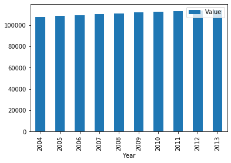

```python
Supply_Year_value.plot(kind='bar')
```

```python
Supply_yearly_value = pd.pivot_table(Food_supply, index = 'Country', columns = 'Year', values = 'Value')
Supply_yearly_value
```

| Year Country | 2004 | 2005 | 2006 | 2007 | 2008 | 2009 | 2010 | 2011 | 2012 | 2013 |
| --- | --- | --- | --- | --- | --- | --- | --- | --- | --- | --- |
| Algeria | 2987 | 2958 | 3047 | 3041 | 3048 | 3110 | 3142 | 3217 | 3272 | 3296 |
| Angola | 2030 | 2077 | 2119 | 2173 | 2245 | 2303 | 2345 | 2407 | 2384 | 2473 |
| Benin | 2461 | 2435 | 2450 | 2564 | 2521 | 2565 | 2555 | 2598 | 2610 | 2619 |
| Botswana | 2191 | 2198 | 2150 | 2166 | 2184 | 2199 | 2234 | 2273 | 2342 | 2326 |
| Burkina Faso | 2505 | 2463 | 2559 | 2546 | 2588 | 2639 | 2681 | 2664 | 2707 | 2720 |
| Cabo Verde | 2523 | 2517 | 2513 | 2574 | 2540 | 2558 | 2524 | 2566 | 2590 | 2609 |
| Cameroon | 2246 | 2311 | 2354 | 2378 | 2446 | 2492 | 2510 | 2573 | 2622 | 2671 |
| Central African Republic | 1989 | 2026 | 2029 | 2090 | 2133 | 2139 | 2164 | 2154 | 2116 | 1879 |
| Chad | 2026 | 2034 | 2022 | 2028 | 2027 | 2021 | 2057 | 2062 | 2124 | 2110 |
| Congo | 2263 | 2043 | 2143 | 2135 | 2110 | 2142 | 2143 | 2185 | 2158 | 2208 |
| Cote d'Ivoire | 2738 | 2787 | 2783 | 2792 | 2739 | 2727 | 2737 | 2784 | 2780 | 2799 |
| Djibouti | 2136 | 2265 | 2314 | 2414 | 2447 | 2466 | 2467 | 2504 | 2545 | 2607 |
| Egypt | 3309 | 3367 | 3389 | 3445 | 3490 | 3441 | 3507 | 3549 | 3561 | 3522 |
| Ethiopia | 1882 | 1978 | 1967 | 1957 | 2018 | 2052 | 2080 | 2103 | 2124 | 2131 |
| Gabon | 2676 | 2715 | 2716 | 2711 | 2653 | 2699 | 2732 | 2772 | 2795 | 2830 |
| Gambia | 2465 | 2442 | 2397 | 2535 | 2589 | 2621 | 2674 | 2692 | 2652 | 2628 |
| Ghana | 2682 | 2751 | 2824 | 2803 | 2950 | 3032 | 3077 | 3002 | 3043 | 3016 |
| Guinea | 2426 | 2443 | 2503 | 2505 | 2534 | 2546 | 2550 | 2546 | 2561 | 2566 |
| Guinea-Bissau | 2257 | 2273 | 2253 | 2293 | 2304 | 2278 | 2346 | 2336 | 2331 | 2292 |
| Kenya | 2022 | 2161 | 2161 | 2110 | 2106 | 2165 | 2160 | 2170 | 2192 | 2206 |
| Lesotho | 2541 | 2567 | 2595 | 2560 | 2558 | 2569 | 2572 | 2550 | 2547 | 2529 |
| Liberia | 2092 | 2160 | 2116 | 2145 | 2227 | 2231 | 2198 | 2254 | 2200 | 2204 |
| Madagascar | 1980 | 2060 | 2083 | 2096 | 2061 | 2065 | 2068 | 2085 | 2058 | 2052 |
| Malawi | 2166 | 2191 | 2269 | 2293 | 2318 | 2311 | 2329 | 2348 | 2333 | 2367 |
| Mali | 2540 | 2583 | 2654 | 2722 | 2777 | 2831 | 2813 | 2832 | 2860 | 2890 |
| Mauritania | 2599 | 2629 | 2603 | 2726 | 2772 | 2762 | 2797 | 2806 | 2873 | 2876 |
| Mauritius | 3023 | 3009 | 3022 | 3076 | 3001 | 3124 | 3151 | 3058 | 3014 | 3065 |
| Morocco | 3263 | 3206 | 3271 | 3251 | 3271 | 3293 | 3294 | 3349 | 3366 | 3403 |
| Mozambique | 2059 | 2038 | 2111 | 2083 | 2164 | 2165 | 2242 | 2259 | 2298 | 2283 |
| Namibia | 2268 | 2243 | 2230 | 2218 | 2120 | 2062 | 2055 | 2090 | 2145 | 2171 |
| Niger | 2453 | 2444 | 2442 | 2461 | 2520 | 2523 | 2533 | 2534 | 2567 | 2547 |
| Nigeria | 2655 | 2705 | 2725 | 2720 | 2723 | 2683 | 2706 | 2706 | 2665 | 2700 |
| Rwanda | 1969 | 2037 | 2044 | 2053 | 2101 | 2196 | 2198 | 2213 | 2270 | 2228 |
| Sao Tome and Principe | 2513 | 2546 | 2554 | 2511 | 2466 | 2435 | 2368 | 2331 | 2338 | 2400 |
| Senegal | 2248 | 2237 | 2310 | 2342 | 2439 | 2446 | 2435 | 2428 | 2443 | 2456 |
| Sierra Leone | 2024 | 2082 | 2155 | 2194 | 2197 | 2251 | 2275 | 2335 | 2374 | 2404 |
| South Africa | 2940 | 2952 | 2927 | 2920 | 2924 | 2936 | 2992 | 3002 | 3014 | 3022 |
| Sudan | 2271 | 2296 | 2331 | 2344 | 2344 | 2346 | 2323 | 2346 | 2301 | 2336 |
| Swaziland | 2469 | 2372 | 2325 | 2310 | 2257 | 2249 | 2284 | 2283 | 2293 | 2329 |
| Togo | 2246 | 2238 | 2283 | 2295 | 2316 | 2340 | 2370 | 2383 | 2414 | 2454 |
| Tunisia | 3248 | 3220 | 3273 | 3252 | 3302 | 3335 | 3326 | 3360 | 3390 | 3349 |
| Uganda | 2351 | 2327 | 2276 | 2212 | 2177 | 2194 | 2200 | 2178 | 2160 | 2130 |
| United Republic of Tanzania | 2098 | 2134 | 2141 | 2215 | 2132 | 2133 | 2097 | 2200 | 2192 | 2208 |
| Zambia | 1866 | 1873 | 1838 | 1781 | 1801 | 1878 | 1904 | 1907 | 1923 | 1930 |
| Zimbabwe | 2044 | 2025 | 2115 | 2109 | 2094 | 2147 | 2168 | 2200 | 2197 | 2110 |

```python
Food_supply.isnull().sum()
```

```
Country    0
Year       0
Value      0
dtype: int64
```

```python
Supply_yearly_value.describe()
```

| Year | 2004 | 2005 | 2006 | 2007 | 2008 | 2009 | 2010 | 2011 | 2012 | 2013 |
| --- | --- | --- | --- | --- | --- | --- | --- | --- | --- | --- |
| count | 45.000000 | 45.000000 | 45.000000 | 45.000000 | 45.000000 | 45.000000 | 45.000000 | 45.000000 | 45.000000 | 45.000000 |
| mean | 2394.222222 | 2409.288889 | 2430.800000 | 2447.755556 | 2460.755556 | 2482.222222 | 2497.400000 | 2515.422222 | 2527.644444 | 2532.244444 |
| std | 374.504272 | 364.728767 | 371.260849 | 374.898481 | 378.895114 | 380.775160 | 385.757307 | 383.728508 | 388.466926 | 396.861274 |
| min | 1866.000000 | 1873.000000 | 1838.000000 | 1781.000000 | 1801.000000 | 1878.000000 | 1904.000000 | 1907.000000 | 1923.000000 | 1879.000000 |
| 25% | 2092.000000 | 2134.000000 | 2143.000000 | 2166.000000 | 2164.000000 | 2194.000000 | 2198.000000 | 2213.000000 | 2200.000000 | 2208.000000 |
| 50% | 2271.000000 | 2311.000000 | 2325.000000 | 2344.000000 | 2439.000000 | 2435.000000 | 2370.000000 | 2407.000000 | 2414.000000 | 2456.000000 |
| 75% | 2541.000000 | 2583.000000 | 2603.000000 | 2711.000000 | 2653.000000 | 2683.000000 | 2706.000000 | 2706.000000 | 2707.000000 | 2720.000000 |
| max | 3309.000000 | 3367.000000 | 3389.000000 | 3445.000000 | 3490.000000 | 3441.000000 | 3507.000000 | 3549.000000 | 3561.000000 | 3522.000000 |

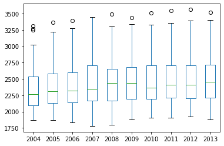

```python
# Box plot to identify outliers present in the data

Supply_yearly_value.plot(kind='box')
```

### An introduction of the population data to the Food Production and Supply data set will help understand better the issue withe Food in Africa

```python
population_data = pd.read_csv('API_SP.POP.TOTL_DS2_en_csv_v2_1308146.csv', skiprows=3)
population_data
```

|  | Country Name | Country Code | Indicator Name | Indicator Code | 1960 | 1961 | 1962 | 1963 | 1964 | 1965 | ... | 2011 | 2012 | 2013 | 2014 | 2015 | 2016 | 2017 | 2018 | 2019 | Unnamed: 64 |
| --- | --- | --- | --- | --- | --- | --- | --- | --- | --- | --- | --- | --- | --- | --- | --- | --- | --- | --- | --- | --- | --- |
| 0 | Aruba | ABW | Population, total | SP.POP.TOTL | 54211.0 | 55438.0 | 56225.0 | 56695.0 | 57032.0 | 57360.0 | ... | 102046.0 | 102560.0 | 103159.0 | 103774.0 | 104341.0 | 104872.0 | 105366.0 | 105845.0 | 106314.0 | NaN |
| 1 | Afghanistan | AFG | Population, total | SP.POP.TOTL | 8996973.0 | 9169410.0 | 9351441.0 | 9543205.0 | 9744781.0 | 9956320.0 | ... | 30117413.0 | 31161376.0 | 32269589.0 | 33370794.0 | 34413603.0 | 35383128.0 | 36296400.0 | 37172386.0 | 38041754.0 | NaN |
| 2 | Angola | AGO | Population, total | SP.POP.TOTL | 5454933.0 | 5531472.0 | 5608539.0 | 5679458.0 | 5735044.0 | 5770570.0 | ... | 24220661.0 | 25107931.0 | 26015780.0 | 26941779.0 | 27884381.0 | 28842484.0 | 29816748.0 | 30809762.0 | 31825295.0 | NaN |
| 3 | Albania | ALB | Population, total | SP.POP.TOTL | 1608800.0 | 1659800.0 | 1711319.0 | 1762621.0 | 1814135.0 | 1864791.0 | ... | 2905195.0 | 2900401.0 | 2895092.0 | 2889104.0 | 2880703.0 | 2876101.0 | 2873457.0 | 2866376.0 | 2854191.0 | NaN |
| 4 | Andorra | AND | Population, total | SP.POP.TOTL | 13411.0 | 14375.0 | 15370.0 | 16412.0 | 17469.0 | 18549.0 | ... | 83747.0 | 82427.0 | 80774.0 | 79213.0 | 78011.0 | 77297.0 | 77001.0 | 77006.0 | 77142.0 | NaN |
| ... | ... | ... | ... | ... | ... | ... | ... | ... | ... | ... | ... | ... | ... | ... | ... | ... | ... | ... | ... | ... | ... |
| 259 | Kosovo | XKX | Population, total | SP.POP.TOTL | 947000.0 | 966000.0 | 994000.0 | 1022000.0 | 1050000.0 | 1078000.0 | ... | 1791000.0 | 1807106.0 | 1818117.0 | 1812771.0 | 1788196.0 | 1777557.0 | 1791003.0 | 1797085.0 | 1794248.0 | NaN |
| 260 | Yemen, Rep. | YEM | Population, total | SP.POP.TOTL | 5315355.0 | 5393036.0 | 5473671.0 | 5556766.0 | 5641597.0 | 5727751.0 | ... | 23807588.0 | 24473178.0 | 25147109.0 | 25823485.0 | 26497889.0 | 27168210.0 | 27834821.0 | 28498687.0 | 29161922.0 | NaN |
| 261 | South Africa | ZAF | Population, total | SP.POP.TOTL | 17099840.0 | 17524533.0 | 17965725.0 | 18423161.0 | 18896307.0 | 19384841.0 | ... | 52004172.0 | 52834005.0 | 53689236.0 | 54545991.0 | 55386367.0 | 56203654.0 | 57000451.0 | 57779622.0 | 58558270.0 | NaN |
| 262 | Zambia | ZMB | Population, total | SP.POP.TOTL | 3070776.0 | 3164329.0 | 3260650.0 | 3360104.0 | 3463213.0 | 3570464.0 | ... | 14023193.0 | 14465121.0 | 14926504.0 | 15399753.0 | 15879361.0 | 16363507.0 | 16853688.0 | 17351822.0 | 17861030.0 | NaN |
| 263 | Zimbabwe | ZWE | Population, total | SP.POP.TOTL | 3776681.0 | 3905034.0 | 4039201.0 | 4178726.0 | 4322861.0 | 4471177.0 | ... | 12894316.0 | 13115131.0 | 13350356.0 | 13586681.0 | 13814629.0 | 14030390.0 | 14236745.0 | 14439018.0 | 14645468.0 | NaN |

264 rows × 65 columns

```python
population_data_required = population_data.loc[:,['Country Name', '2004', '2005','2006', '2007', '2008', '2009', '2010', '2011', '2012', '2013']]
population_data_required
```

|  | Country Name | 2004 | 2005 | 2006 | 2007 | 2008 | 2009 | 2010 | 2011 | 2012 | 2013 |
| --- | --- | --- | --- | --- | --- | --- | --- | --- | --- | --- | --- |
| 0 | Aruba | 98737.0 | 100031.0 | 100834.0 | 101222.0 | 101358.0 | 101455.0 | 101669.0 | 102046.0 | 102560.0 | 103159.0 |
| 1 | Afghanistan | 24726684.0 | 25654277.0 | 26433049.0 | 27100536.0 | 27722276.0 | 28394813.0 | 29185507.0 | 30117413.0 | 31161376.0 | 32269589.0 |
| 2 | Angola | 18758145.0 | 19433602.0 | 20149901.0 | 20905363.0 | 21695634.0 | 22514281.0 | 23356246.0 | 24220661.0 | 25107931.0 | 26015780.0 |
| 3 | Albania | 3026939.0 | 3011487.0 | 2992547.0 | 2970017.0 | 2947314.0 | 2927519.0 | 2913021.0 | 2905195.0 | 2900401.0 | 2895092.0 |
| 4 | Andorra | 76244.0 | 78867.0 | 80993.0 | 82684.0 | 83862.0 | 84463.0 | 84449.0 | 83747.0 | 82427.0 | 80774.0 |
| ... | ... | ... | ... | ... | ... | ... | ... | ... | ... | ... | ... |
| 259 | Kosovo | 1704622.0 | 1705780.0 | 1719536.0 | 1733404.0 | 1747383.0 | 1761474.0 | 1775680.0 | 1791000.0 | 1807106.0 | 1818117.0 |
| 260 | Yemen, Rep. | 19540098.0 | 20107409.0 | 20687646.0 | 21282515.0 | 21892146.0 | 22516460.0 | 23154855.0 | 23807588.0 | 24473178.0 | 25147109.0 |
| 261 | South Africa | 47291610.0 | 47880601.0 | 48489459.0 | 49119759.0 | 49779471.0 | 50477011.0 | 51216964.0 | 52004172.0 | 52834005.0 | 53689236.0 |
| 262 | Zambia | 11550642.0 | 11856247.0 | 12173514.0 | 12502958.0 | 12848530.0 | 13215139.0 | 13605984.0 | 14023193.0 | 14465121.0 | 14926504.0 |
| 263 | Zimbabwe | 12019912.0 | 12076699.0 | 12155491.0 | 12255922.0 | 12379549.0 | 12526968.0 | 12697723.0 | 12894316.0 | 13115131.0 | 13350356.0 |

264 rows × 11 columns

```python
population_data_required.describe()
```

|  | 2004 | 2005 | 2006 | 2007 | 2008 | 2009 | 2010 | 2011 | 2012 | 2013 |
| --- | --- | --- | --- | --- | --- | --- | --- | --- | --- | --- |
| count | 2.630000e+02 | 2.630000e+02 | 2.630000e+02 | 2.630000e+02 | 2.630000e+02 | 2.630000e+02 | 2.630000e+02 | 2.630000e+02 | 2.620000e+02 | 2.620000e+02 |
| mean | 2.569406e+08 | 2.603340e+08 | 2.637517e+08 | 2.671895e+08 | 2.706754e+08 | 2.741823e+08 | 2.776952e+08 | 2.811942e+08 | 2.858398e+08 | 2.894748e+08 |
| std | 8.202006e+08 | 8.304701e+08 | 8.407653e+08 | 8.510724e+08 | 8.614903e+08 | 8.719804e+08 | 8.824872e+08 | 8.930248e+08 | 9.052617e+08 | 9.160822e+08 |
| min | 9.869000e+03 | 9.849000e+03 | 9.828000e+03 | 9.842000e+03 | 9.891000e+03 | 9.939000e+03 | 1.000500e+04 | 1.005700e+04 | 1.027900e+04 | 1.082100e+04 |
| 25% | 1.301808e+06 | 1.320716e+06 | 1.324686e+06 | 1.324566e+06 | 1.386878e+06 | 1.409218e+06 | 1.427037e+06 | 1.449584e+06 | 1.409858e+06 | 1.427339e+06 |
| 50% | 8.306500e+06 | 8.391850e+06 | 8.484550e+06 | 8.581300e+06 | 8.763400e+06 | 9.142259e+06 | 9.378126e+06 | 9.460830e+06 | 9.624311e+06 | 9.746730e+06 |
| 75% | 4.832350e+07 | 4.856724e+07 | 4.889525e+07 | 4.937062e+07 | 4.985456e+07 | 5.036369e+07 | 5.090889e+07 | 5.149739e+07 | 5.247893e+07 | 5.323004e+07 |
| max | 6.431552e+09 | 6.511748e+09 | 6.592735e+09 | 6.674204e+09 | 6.756918e+09 | 6.839574e+09 | 6.921872e+09 | 7.002861e+09 | 7.085763e+09 | 7.169640e+09 |

```python
population_data_required.rename(columns={'Country Name':'Country'}, inplace=True)
population_data_required
```

|  | Country | 2004 | 2005 | 2006 | 2007 | 2008 | 2009 | 2010 | 2011 | 2012 | 2013 |
| --- | --- | --- | --- | --- | --- | --- | --- | --- | --- | --- | --- |
| 0 | Aruba | 98737.0 | 100031.0 | 100834.0 | 101222.0 | 101358.0 | 101455.0 | 101669.0 | 102046.0 | 102560.0 | 103159.0 |
| 1 | Afghanistan | 24726684.0 | 25654277.0 | 26433049.0 | 27100536.0 | 27722276.0 | 28394813.0 | 29185507.0 | 30117413.0 | 31161376.0 | 32269589.0 |
| 2 | Angola | 18758145.0 | 19433602.0 | 20149901.0 | 20905363.0 | 21695634.0 | 22514281.0 | 23356246.0 | 24220661.0 | 25107931.0 | 26015780.0 |
| 3 | Albania | 3026939.0 | 3011487.0 | 2992547.0 | 2970017.0 | 2947314.0 | 2927519.0 | 2913021.0 | 2905195.0 | 2900401.0 | 2895092.0 |
| 4 | Andorra | 76244.0 | 78867.0 | 80993.0 | 82684.0 | 83862.0 | 84463.0 | 84449.0 | 83747.0 | 82427.0 | 80774.0 |
| ... | ... | ... | ... | ... | ... | ... | ... | ... | ... | ... | ... |
| 259 | Kosovo | 1704622.0 | 1705780.0 | 1719536.0 | 1733404.0 | 1747383.0 | 1761474.0 | 1775680.0 | 1791000.0 | 1807106.0 | 1818117.0 |
| 260 | Yemen, Rep. | 19540098.0 | 20107409.0 | 20687646.0 | 21282515.0 | 21892146.0 | 22516460.0 | 23154855.0 | 23807588.0 | 24473178.0 | 25147109.0 |
| 261 | South Africa | 47291610.0 | 47880601.0 | 48489459.0 | 49119759.0 | 49779471.0 | 50477011.0 | 51216964.0 | 52004172.0 | 52834005.0 | 53689236.0 |
| 262 | Zambia | 11550642.0 | 11856247.0 | 12173514.0 | 12502958.0 | 12848530.0 | 13215139.0 | 13605984.0 | 14023193.0 | 14465121.0 | 14926504.0 |
| 263 | Zimbabwe | 12019912.0 | 12076699.0 | 12155491.0 | 12255922.0 | 12379549.0 | 12526968.0 | 12697723.0 | 12894316.0 | 13115131.0 | 13350356.0 |

264 rows × 11 columns

```python
population_data_required = pd.melt(population_data_required, id_vars=['Country'], var_name='Year')
population_data_required
```

|  | Country | Year | value |
| --- | --- | --- | --- |
| 0 | Aruba | 2004 | 98737.0 |
| 1 | Afghanistan | 2004 | 24726684.0 |
| 2 | Angola | 2004 | 18758145.0 |
| 3 | Albania | 2004 | 3026939.0 |
| 4 | Andorra | 2004 | 76244.0 |
| ... | ... | ... | ... |
| 2635 | Kosovo | 2013 | 1818117.0 |
| 2636 | Yemen, Rep. | 2013 | 25147109.0 |
| 2637 | South Africa | 2013 | 53689236.0 |
| 2638 | Zambia | 2013 | 14926504.0 |
| 2639 | Zimbabwe | 2013 | 13350356.0 |

2640 rows × 3 columns

```python
Food_data = pd.merge(Food_Country, population_data_required, how='left', on='Country')
Food_data
```

|  | Country | Value | Year | value |
| --- | --- | --- | --- | --- |
| 0 | Algeria | 15536 | 2004 | 32692163.0 |
| 1 | Algeria | 15536 | 2005 | 33149724.0 |
| 2 | Algeria | 15536 | 2006 | 33641002.0 |
| 3 | Algeria | 15536 | 2007 | 34166972.0 |
| 4 | Algeria | 15536 | 2008 | 34730608.0 |
| ... | ... | ... | ... | ... |
| 4045 | Zimbabwe | 7914 | 2009 | 12526968.0 |
| 4046 | Zimbabwe | 7914 | 2010 | 12697723.0 |
| 4047 | Zimbabwe | 7914 | 2011 | 12894316.0 |
| 4048 | Zimbabwe | 7914 | 2012 | 13115131.0 |
| 4049 | Zimbabwe | 7914 | 2013 | 13350356.0 |

4050 rows × 4 columns

```python
Food_data = pd.merge(Food_data, consumption_Country, how='left', on='Country')
Food_data
```

|  | Country | Value_x | Year | value | Value_y |
| --- | --- | --- | --- | --- | --- |
| 0 | Algeria | 15536 | 2004 | 32692163.0 | 2987 |
| 1 | Algeria | 15536 | 2004 | 32692163.0 | 2958 |
| 2 | Algeria | 15536 | 2004 | 32692163.0 | 3047 |
| 3 | Algeria | 15536 | 2004 | 32692163.0 | 3041 |
| 4 | Algeria | 15536 | 2004 | 32692163.0 | 3048 |
| ... | ... | ... | ... | ... | ... |
| 40495 | Zimbabwe | 7914 | 2013 | 13350356.0 | 2147 |
| 40496 | Zimbabwe | 7914 | 2013 | 13350356.0 | 2168 |
| 40497 | Zimbabwe | 7914 | 2013 | 13350356.0 | 2200 |
| 40498 | Zimbabwe | 7914 | 2013 | 13350356.0 | 2197 |
| 40499 | Zimbabwe | 7914 | 2013 | 13350356.0 | 2110 |

40500 rows × 5 columns

```python
Food_data.rename(columns={'Value_x':'Production'}, inplace=True)
```

```python
Food_data.rename(columns={'Value_y':'Consumption'}, inplace=True)
```

```python
Food_data.rename(columns={'value':'Population'}, inplace=True)
```

```python
Food_data
```

|  | Country | Production | Year | Population | Consumption |
| --- | --- | --- | --- | --- | --- |
| 0 | Algeria | 15536 | 2004 | 32692163.0 | 2987 |
| 1 | Algeria | 15536 | 2004 | 32692163.0 | 2958 |
| 2 | Algeria | 15536 | 2004 | 32692163.0 | 3047 |
| 3 | Algeria | 15536 | 2004 | 32692163.0 | 3041 |
| 4 | Algeria | 15536 | 2004 | 32692163.0 | 3048 |
| ... | ... | ... | ... | ... | ... |
| 40495 | Zimbabwe | 7914 | 2013 | 13350356.0 | 2147 |
| 40496 | Zimbabwe | 7914 | 2013 | 13350356.0 | 2168 |
| 40497 | Zimbabwe | 7914 | 2013 | 13350356.0 | 2200 |
| 40498 | Zimbabwe | 7914 | 2013 | 13350356.0 | 2197 |
| 40499 | Zimbabwe | 7914 | 2013 | 13350356.0 | 2110 |

40500 rows × 5 columns

```python
Food_data = Food_data[Food_data.Production > 0]
```

```python
Food_data = Food_data.dropna(how='any')
```

#### What is the correlation between the Production rate, Population and Consumption rate?

```python
Food_data.corr(method='pearson')
```

|  | Production | Population | Consumption |
| --- | --- | --- | --- |
| Production | 1.000000 | 0.936990 | 0.185014 |
| Population | 0.936990 | 1.000000 | 0.093591 |
| Consumption | 0.185014 | 0.093591 | 1.000000 |

#### The Correlation result shows some very intresting information

###### 1. It shows that the Population Growth is more strongly correlated to the Production rate that the consumption rate

###### 2. The Consumption rate is not related to the population growth and less correlated to the Production rate

### Why is there no Correlation between the Consumption rate and Production rate / Population?

#### A pair plot to show the distribution and Relationship between the various variables

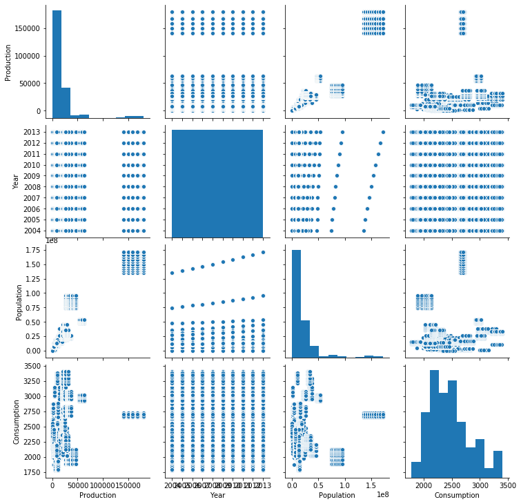

```python
sns.pairplot(Food_data)
```

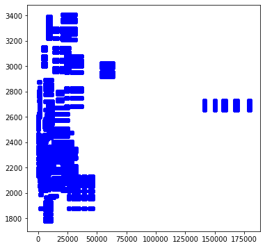

```python
plt.figure(figsize=(6,6))
plt.scatter(Food_data['Production'], Food_data.Consumption, color='b')
```

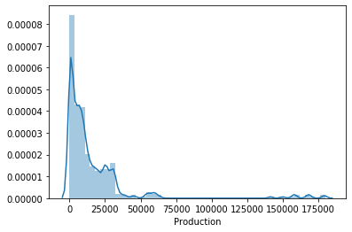

```python
sns.distplot(Food_data['Production'])
```

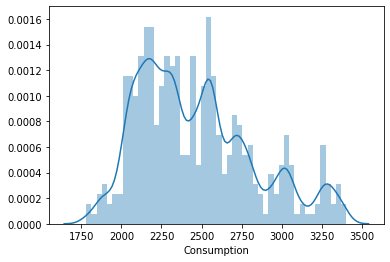

```python
sns.distplot(Food_data['Consumption'])
```

### The distribution plot shows that the Food Consumed/Supplied in Africa is more evenly distributed than the food produced and a larger percentage of countries consume on an average 2200kt/year

#### A conbined View of the joint plot that shows the disperity between Food Production and Consumption

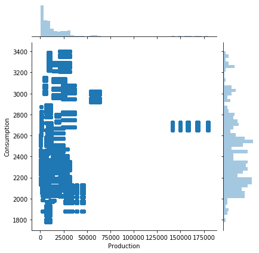

```python
sns.jointplot(Food_data['Production'], Food_data.Consumption)
```

#### The kde joint plot, the darker regions shoes where the larger percentage of both food production and Consumption fall

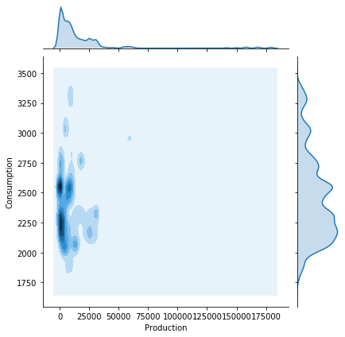

```python
sns.jointplot(Food_data['Production'], Food_data.Consumption, kind='kde')
```

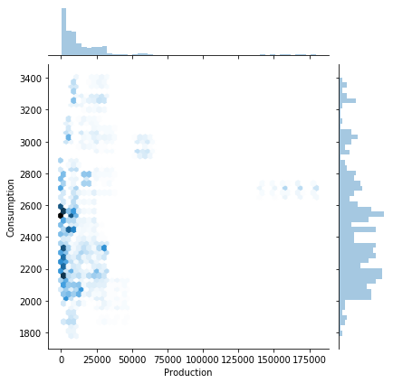

```python
sns.jointplot(Food_data['Production'], Food_data.Consumption, kind='hex')
```

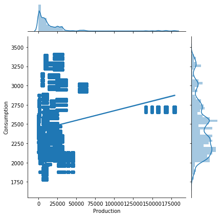

```python
sns.jointplot(Food_data['Production'], Food_data.Consumption, data=Food_data, kind='reg')
```

# A pair grip map of all variables

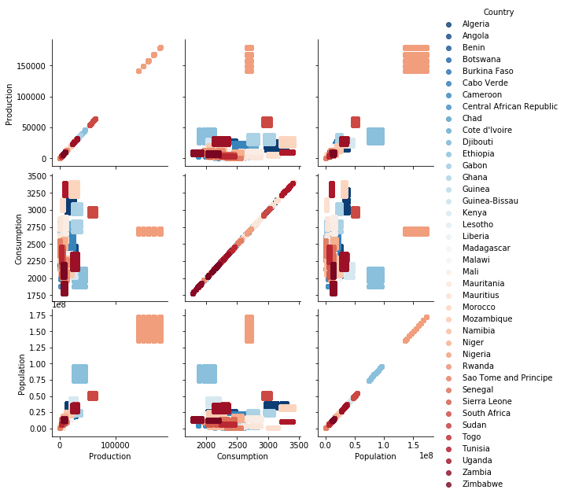

```python
g = sns.PairGrid(Food_data, vars=['Production', 'Consumption', 'Population'],
                hue='Country', palette='RdBu_r')
g.map(plt.scatter, alpha=0.8)
g.add_legend();
```